# course_project

nicopardo

27 5 2020

This is the final project for the course practical machine learning in coursera. The Idea of the project is to apply machine learning methods to a real life data set. The setting of the exercise is Human Activity Recognition (HAM) for weight lifting. The idea is to identify the type of activity a person is performing and how well the person is performing the activity. The information available for the identification of the activity is the output of wearable accelerometers in different parts of the body.

# Setting

here is an extract explaining the setting of the analysis taken from the description of the exercise in the course page: “Six young health participants were asked to perform one set of 10 repetitions of the Unilateral Dumbbell Biceps Curl in five different fashions: exactly according to the specification (Class A), throwing the elbows to the front (Class B), lifting the dumbbell only halfway (Class C), lowering the dumbbell only halfway (Class D) and throwing the hips to the front (Class E)”. The idea is to use features created from output of the accelerometers to classify the activity being performed.

# Data loading and processing

load the libraries and set seed:

```r
library(caret)
library(dplyr)
library(lubridate)
library(corrplot)
library(checkmate)
library(rpart)
library(rattle)

set.seed(1234)
```

Next I download the training and testing sets from the webpage given in the course:

```r
download.file("https://d396qusza40orc.cloudfront.net/predmachlearn/pml-training.csv", destfile = "pml-training.csv")
download.file("https://d396qusza40orc.cloudfront.net/predmachlearn/pml-testing.csv", destfile = "pml-testing.csv")

training <- read.csv("pml-training.csv")
quiz <- read.csv("pml-testing.csv")
```

Now i quickly check that the number of classes and subjects match the description of the dataset

```r
table(training$classe)
```

```
##
##    A    B    C    D    E
## 5580 3797 3422 3216 3607
```

```r
table(training$user_name)
```

```
##
##   adelmo carlitos  charles   eurico   jeremy    pedro
##     3892     3112     3536     3070     3402     2610
```

There are indeed 5 classes: A, B, C, D and E. And 6 subjects.

## Cross validation

For cross validation, I will split the training data into a training set containing 60% of the training data set, to train the models. And a test set, with the remaining 40% of the training data set to calculate the accuracy of the predictions. Then I will predict the activities for the quiz data set using the model that performs best.

```r
intrain <- createDataPartition(y= training$classe, p=0.6, list = FALSE)
training_set <- training[intrain,]
test_set <- training[-intrain,]
```

I will then use the *training_set* for further processing of the data and features selection

## Features selection

First I take a look at variables containing missing values. For this I look for missing values in each variable, calculate the percentage of missing values in each variable and save the index of the variables with missing observations

```r
missing <- tbl_df(data.frame(lapply(training_set, function(x) sum(is.na(x))/dim(training_set)[1])))
vars_w_missing <- select_if(missing, function(x) mean(x)>0)
vars_w_missing_index <- which(names(training_set) %in% names(vars_w_missing) )
```

For the variables with missing observations, 97% of the observations are missing values. Missing observatoins are distributed across classes and user names and they appear in the same accelerometer outcome for the different measurement devices. Since these variables only have a small number of useful observations, imputation would not make much sense, therefore I will exclude them from the analysis.

In a next step I check for variables with very little variability, and collect the indexes of the variables flagged as having near zero variability by the function. I then remove all variables with missing values and near zero variability

```r
nzv <- nearZeroVar(training_set, saveMetrics = T)
nzv_index <- nearZeroVar(training_set)

#check for variables with both missing values and near zero variability:
index_in_common <- intersect(nzv_index, vars_w_missing_index)
all_indexes_to_exclude <- union(nzv_index, vars_w_missing_index)

#remove all "problematic" variables
training_set_final <- training_set[,-all_indexes_to_exclude]
```

Finally, I discard some variables that arguably do not add any information for the prediction of the classes, namely id related variables and time stamps

```r
training_set_final_2 <- training_set_final[,-c(1:5)]
dim(training_set_final_2)
```

```
## [1] 11776    54
```

Next I take a rough look at apparent correlations of the remaining features in the training set

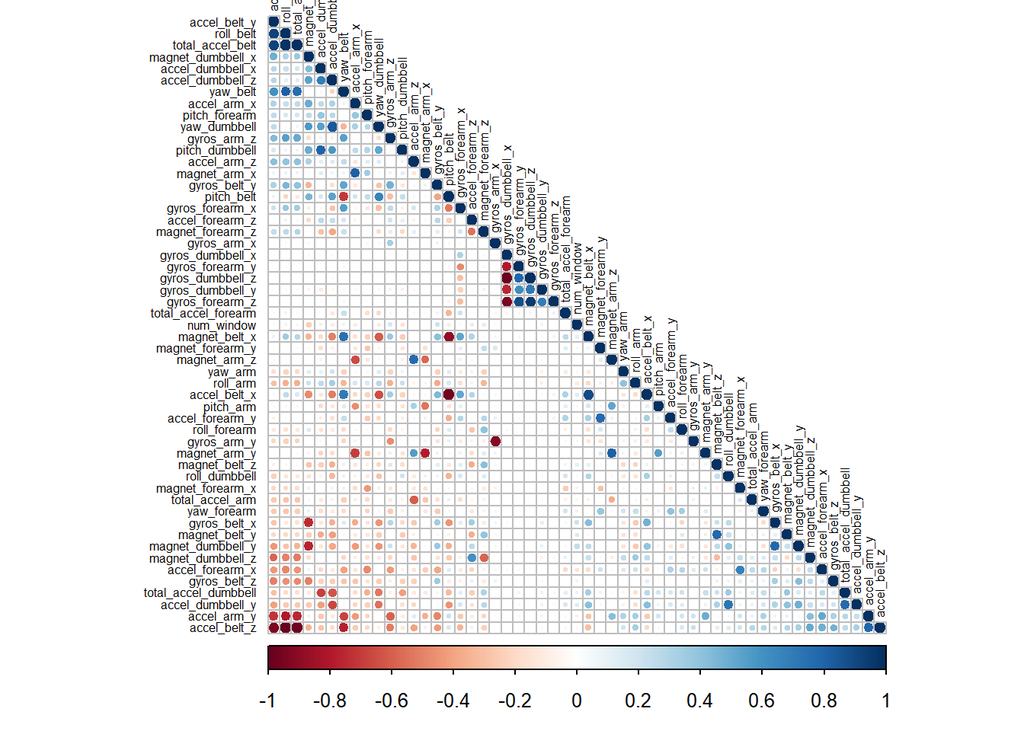

```r
corrmat <- cor(training_set_final_2[,-54])
plot_corrmat <- corrplot(corrmat, order = "FPC", tl.cex = 0.5, tl.col = "black", type = "lower")
```

The graph shows that there are some high correlations between different variables. However, high correlations do not appear to be widespread in the data, therefore this does not seem to pose any significant problem for the analysis, so I will not discard correlated variables from the analysis.

Finally, I have perform the same variable selection for the test set and the quiz set

```r
#test set
test_set_final <- test_set[,-all_indexes_to_exclude]
test_set_final_2 <- test_set_final[,-c(1:5)]

#quiz set
quiz_final <- quiz[,-all_indexes_to_exclude]
quiz_final_2 <- quiz_final[,-c(1:5)]
```

# Training algorithms

For the prediction of the activities I will use three models: decision trees, random forest and generalized boosting models. Then I will pick the model that predicts the outcomes with the highest accuracy and efficiency.

First I start with a decision tree. In the code below I train the algorithm using the rpart package, then I show a dendrogram of the decision tree and then use the model fit to predict the activities in the test set. Then I present the accuracy of the model.

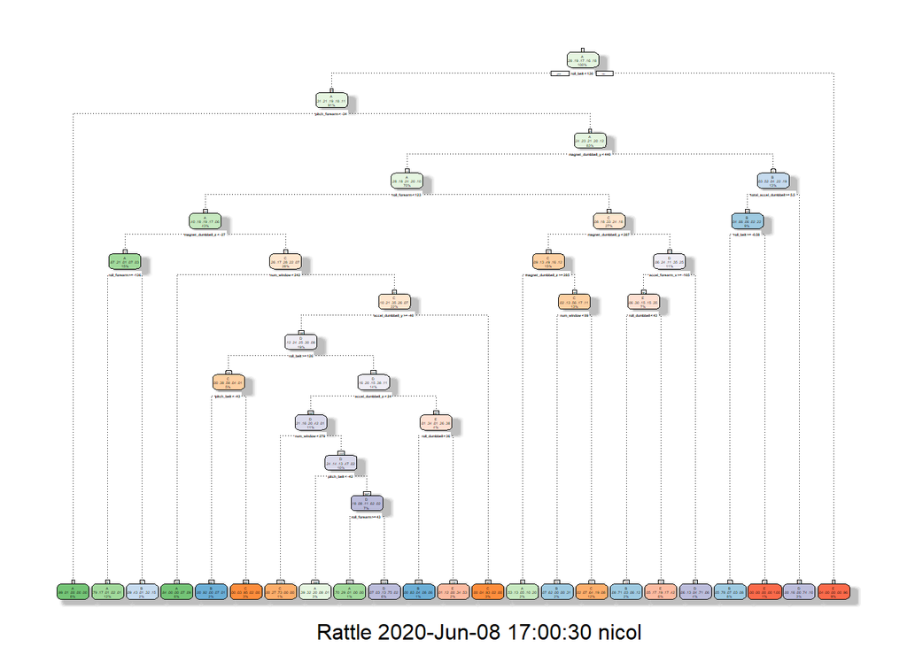

```r
fit_dt <- rpart(classe~., method="class", data = training_set_final_2)
fancyRpartPlot(fit_dt)
```

```r
pred_dt <- predict(fit_dt, test_set_final_2, type = "class")
confmat_dt <- confusionMatrix(pred_dt, test_set_final_2$classe)
confmat_dt
```

```
## Confusion Matrix and Statistics
##
##           Reference
## Prediction    A    B    C    D    E
##          A 2017  299   61   84   94
##          B   94  908   55  108  167
##          C    7   96 1074  168   73
##          D   59   92   71  761   59
##          E   55  123  107  165 1049
##
## Overall Statistics
##
##                Accuracy : 0.7404
##                  95% CI : (0.7305, 0.7501)
##     No Information Rate : 0.2845
##     P-Value [Acc > NIR] : < 2.2e-16
##
##                   Kappa : 0.6697
##
##  Mcnemar's Test P-Value : < 2.2e-16
##
## Statistics by Class:
##
##                      Class: A Class: B Class: C Class: D Class: E
## Sensitivity            0.9037   0.5982   0.7851  0.59176   0.7275
## Specificity            0.9042   0.9330   0.9469  0.95716   0.9297
## Pos Pred Value         0.7894   0.6817   0.7574  0.73033   0.6998
## Neg Pred Value         0.9594   0.9064   0.9543  0.92284   0.9381
## Prevalence             0.2845   0.1935   0.1744  0.16391   0.1838
## Detection Rate         0.2571   0.1157   0.1369  0.09699   0.1337
## Detection Prevalence   0.3256   0.1698   0.1807  0.13281   0.1911
## Balanced Accuracy      0.9039   0.7656   0.8660  0.77446   0.8286
```

```r
accuracy_dt <- confmat_dt$overall[[1]]
accuracy_dt
```

```
## [1] 0.7403773
```

The model has an accuracy of 0.7403773 and a corresponding estimated out-of-sample error of 0.2596227.

Next I run random forest to predict the classes using the caret package. I then present measures of accuracy of the model in the test set.

```r
fit_rf <- train(classe~., method="rf", data=training_set_final_2)
pred_rf <- predict(fit_rf, test_set_final_2)
confmat_rf <- confusionMatrix(pred_rf, test_set_final_2$classe)
confmat_rf
```

```
## Confusion Matrix and Statistics
##
##           Reference
## Prediction    A    B    C    D    E
##          A 2232    5    0    0    0
##          B    0 1511    5    0    0
##          C    0    1 1363    3    0
##          D    0    1    0 1283    5
##          E    0    0    0    0 1437
##
## Overall Statistics
##
##                Accuracy : 0.9975
##                  95% CI : (0.9961, 0.9984)
##     No Information Rate : 0.2845
##     P-Value [Acc > NIR] : < 2.2e-16
##
##                   Kappa : 0.9968
##
##  Mcnemar's Test P-Value : NA
##
## Statistics by Class:
##
##                      Class: A Class: B Class: C Class: D Class: E
## Sensitivity            1.0000   0.9954   0.9963   0.9977   0.9965
## Specificity            0.9991   0.9992   0.9994   0.9991   1.0000
## Pos Pred Value         0.9978   0.9967   0.9971   0.9953   1.0000
## Neg Pred Value         1.0000   0.9989   0.9992   0.9995   0.9992
## Prevalence             0.2845   0.1935   0.1744   0.1639   0.1838
## Detection Rate         0.2845   0.1926   0.1737   0.1635   0.1832
## Detection Prevalence   0.2851   0.1932   0.1742   0.1643   0.1832
## Balanced Accuracy      0.9996   0.9973   0.9979   0.9984   0.9983
```

```r
accuracy_rf <- confmat_rf$overall[[1]]
accuracy_rf
```

```
## [1] 0.9974509
```

The model performs very well, with an accuracy of 0.9974509, therefore the expected out of sample error is very small, 0.0025491. However one has to bear in mind that there is a possibility that the model is overfitting the data.

```r
fit_boost <- train(classe~., method="gbm", data = training_set_final_2, verbose=F)
pred_boost <- predict(fit_boost, training_set_final_2)
confmat_boost <- confusionMatrix(pred_boost, training_set_final_2$classe)
confmat_boost
```

```
## Confusion Matrix and Statistics
##
##           Reference
## Prediction    A    B    C    D    E
##          A 3341   11    0    0    0
##          B    5 2258   10    1    3
##          C    1   10 2040   13    2
##          D    1    0    2 1915   15
##          E    0    0    2    1 2145
##
## Overall Statistics
##
##                Accuracy : 0.9935
##                  95% CI : (0.9918, 0.9948)
##     No Information Rate : 0.2843
##     P-Value [Acc > NIR] : < 2.2e-16
##
##                   Kappa : 0.9917
##
##  Mcnemar's Test P-Value : NA
##
## Statistics by Class:
##
##                      Class: A Class: B Class: C Class: D Class: E
## Sensitivity            0.9979   0.9908   0.9932   0.9922   0.9908
## Specificity            0.9987   0.9980   0.9973   0.9982   0.9997
## Pos Pred Value         0.9967   0.9917   0.9874   0.9907   0.9986
## Neg Pred Value         0.9992   0.9978   0.9986   0.9985   0.9979
## Prevalence             0.2843   0.1935   0.1744   0.1639   0.1838
## Detection Rate         0.2837   0.1917   0.1732   0.1626   0.1822
## Detection Prevalence   0.2846   0.1934   0.1754   0.1641   0.1824
## Balanced Accuracy      0.9983   0.9944   0.9953   0.9952   0.9952
```

```r
accuracy_boost <- confmat_boost$overall[[1]]
accuracy_boost
```

```
## [1] 0.9934613
```

# Quiz part

Here I use random forest to predict the classes in the quiz set

```r
quiz_prediction <- predict(fit_rf, quiz_final_2)
quiz_prediction
```

```
##  [1] B A B A A E D B A A B C B A E E A B B B
## Levels: A B C D E
```